# PRS tutorial

Ziqiao Wang

2024-11-12

# 1 Calculate PRS using pre-trained weights

## 1.1 Download Summary Statistics from PGSCatalog

First, we look for the available pre-trained PRS weights from PGSCatalog, see https://www.pgscatalog.org/. Note that to use this, we need to make sure that there is no overlap between our data and the original GWAS, as well as the training sample in PGSCatalog. For downstream analyses, sample relatedness is another issue. A high degree of relatedness between individuals between the base and target data can also generate inflation of the association between the PRS and target phenotype.

Pay attention to the Genome build (HG19 or HG38) of your own data. As an example, let’s use pre-trained PRS weights for BMI: https://www.pgscatalog.org/score/PGS001943/. Ensure that the base and target data SNPs have genomic positions assigned on the same genome build. LiftOver is an excellent tool for standardizing genome build across different data sets.

## 1.2 Data cleaning

### 1.2.1 Ambiguous SNPs

Here, we use the 1000Genome project Phase 3 data. Our data version is HG19. If the base and target data were generated using different genotyping chips, and the chromosome strand (+/−) that was used for either is unknown, then it is not possible to pair up the alleles of ambiguous SNPs (i.e., those with complementary alleles, either C/G or A/T SNPs) across the data sets, because it will be unknown whether the base and target data are referring to the same allele or not. While allele frequencies could be used to infer which alleles are on the same strand, the accuracy of this could be low for SNPs with MAF close to $50\%$ or when the base and target data are from different populations. Therefore, we recommend removing all ambiguous/palindromic SNPs to avoid introducing this potential source of systematic error.

```r
library(data.table)
pgs_weights <- fread("PGS001943_hmPOS_GRCh37.txt.gz", header = T)
head(pgs_weights)
#remove ambiguous snps
rm_id=which( (pgs_weights$effect_allele=="A" & pgs_weights$other_allele=="T") |
               (pgs_weights$effect_allele=="T" & pgs_weights$other_allele=="A") |
               (pgs_weights$effect_allele=="C" & pgs_weights$other_allele=="G") |
               (pgs_weights$effect_allele=="G" & pgs_weights$other_allele=="C") )
rm_id
#pgs_weights=pgs_weights[-rm_id,]
```

### 1.2.2 Standard GWAS QC (will do this step when calculating the PRS)

We recommend the following QC criteria for standard analyses: genotyping rate $>0.99$, sample missingness $<0.02$, Hardy-Weinberg Equilibrium P $>1 × 10^{−6}$, heterozygosity within 3 standard deviations of the mean, minor allele frequency (MAF) $>1\%$ (MAF $>5\%$ if target sample $N <1000$) and imputation ‘info score’ $>0.8$. If both the base and target data are large (e.g., $N >50\,000$), then SNPs with MAF $<1\%$ may be included, in which case we recommend a minor allele count $>100$ in the base and target data to ensure the integrity of normality assumptions implicit in association testing and LD calculation.

### 1.2.3 Mismatching SNPs and/or Duplicate SNPs

SNPs that have mismatching alleles reported in the base and target data are either resolvable by strand-flipping the alleles to their complementary alleles in, for example, the target data, such as for a SNP with A/C in the base data and G/T in the target, or non-resolvable, such as for a SNP with C/G in the base and C/T in the target. Most polygenic score software programs perform strand-flipping automatically for SNPs that are resolvable and remove non-resolvable mismatching SNPs. Ensure that there are no duplicated SNPs in either the base or target data.

```r
#Identify SNPs that require strand flipping
bim <- read.table("mergedplink.bim")
colnames(bim) <- c("hm_chr", "snp", "CM", "hm_pos", "B.A1", "B.A2")

# Change all alleles to upper case for easy comparison
pgs_weights$effect_allele <- toupper(pgs_weights$effect_allele)
pgs_weights$other_allele <- toupper(pgs_weights$other_allele)
bim$B.A1 <- toupper(bim$B.A1)
bim$B.A2 <- toupper(bim$B.A2)

# Merge summary statistic with target
library(dplyr)
snp_clean <- pgs_weights %>%
  distinct(.keep_all = TRUE)

info <- merge(bim, pgs_weights, by = c("hm_chr", "hm_pos"))

id=which( ((info$B.A1 == info$effect_allele) | (info$B.A1 == info$other_allele)) & ((info$B.A2 == info$effect_allele) | (info$B.A2 == info$other_allele)) )
length(id)
#since all alleles were match in our example data, we can go ahead and use this set of info scores.

#otherwise, let's do some strand flipping
# Function for finding the complementary allele
# complement <- function(x) {
#   switch (
#     x,
#     "A" = "T",
#     "C" = "G",
#     "T" = "A",
#     "G" = "C",
#     return(NA)
#   )
# }
#
#
# # Identify SNPs that are complementary between base and target
# info$effect_allele.complement <- sapply(info$effect_allele, complement)
# info$other_allele.complement <- sapply(info$other_allele, complement)
# id_complement = which( ((info$B.A1 == info$effect_allele.complement) | (info$B.A1 == info$other_allele.complement)) & ((info$B.A2 == info$effect_allele.complement) | (info$B.A2 == info$other_allele.complement)) )
# # Update the complementary alleles in the info file
# # This allow us to match the allele in subsequent analysis
# info$effect_allele[id_complement] <- info$effect_allele.complement[id_complement]
# info$other_allele[id_complement] <- info$other_allele.complement[id_complement]


info_score=info[,c("snp","effect_allele","effect_weight")]
dim(info_score)
```

### 1.2.4 Save the score file for PLINK

```r
#save this file for calculating scores in plink
write.table(info_score,file="bmi_score.txt",row.names = F,col.names = F,quote = F)
```

Other software tools for data harmonization: [TwoSampleMR](https://mrcieu.github.io/TwoSampleMR/articles/introduction.html)

## 1.3 Calculation of PRS

This will be done in PLINK2.0

```r
####################
/dcs04/nilanjan/data/zwang/tools/20240105/plink2 \
--threads 5 \
--rm-dup exclude-all \
--mach-r2-filter \
--maf 0.01 \
--hwe 1e-6 \
--geno 0.01 \
--mind 0.01 \
--bfile /dcs04/nilanjan/data/zwang/1000G/EUR/data/mergedplink \
--score /dcs04/nilanjan/data/zwang/PGScalculation/plink/bmi_score.txt cols=+scoresums,-scoreavgs \
--score-col-nums 3 \
--out /dcs04/nilanjan/data/zwang/PGScalculation/example/bmi_prive_prs

#https://zzz.bwh.harvard.edu/plink/profile.shtml
```

## 1.4 Visualize the PRS

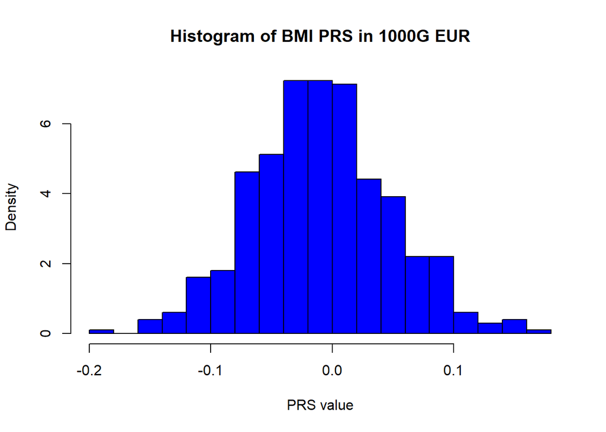

```r
library(data.table)
prs_bmi <- fread("bmi_prive_prs.sscore", header = T)
hist(prs_bmi$SCORE1_SUM, col = "blue", breaks = 20, xlab = "PRS value", main = "Histogram of BMI PRS in 1000G EUR", freq = F)
```

# 2 Train PRS models using GWAS summary statistics

First, download GWAS summary statistics from [GWASCatalog](https://www.ebi.ac.uk/gwas/). We use the example dataset for ADHD (available for download [here](https://github.com/ziqiaow/PRS-tutorial)). Second, install PRScs into your computer or computing server [Instructions](https://github.com/getian107/PRScs).

## 2.1 Next prepare the summary statistics for PRScs

```r
library(data.table)
adhd = fread("ADHD2022_iPSYCH_deCODE_PGC.meta.gz")

#create input for PRScs
sum_stats = adhd[,c("SNP","A1","A2","OR","P")]
write.table(sum_stats,file="sum_stats.txt",col.names = T,row.names = F,quote = F)
```

## 2.2 Calculate the effect size of GWAS for case-control study

https://rdrr.io/github/neurogenomics/MungeSumstats/man/compute_sample_size.html

4/(1/N_case+1/N_control)

In the original ADHD paper, N_case = 38691, N_control = 186843

```r
4/(1/38691+1/186843)
#128213.8
```

## 2.3 Run PRScs

First download the reference LD panels. Specify your paths of the data, genotype data, and output file.

```r
python PRScs.py --ref_dir=PATH_TO_REFERENCE --bim_prefix=VALIDATION_BIM_PREFIX --sst_file=SUM_STATS_FILE --n_gwas=GWAS_SAMPLE_SIZE --out_dir=OUTPUT_DIR [--a=PARAM_A --b=PARAM_B --phi=PARAM_PHI --n_iter=MCMC_ITERATIONS --n_burnin=MCMC_BURNIN --thin=MCMC_THINNING_FACTOR --chrom=CHROM --beta_std=BETA_STD --write_psi=WRITE_PSI --write_pst=WRITE_POSTERIOR_SAMPLES --seed=SEED]


python PRScs.py --ref_dir=/dcs04/nilanjan/data/zwang/phewas/LD/ldblk_ukbb_eur --bim_prefix=/dcs04/nilanjan/data/zwang/phewas/plink/data/mergedplink --sst_file=/dcs04/nilanjan/data/zwang/PRS_adhd/prscs_results/sum_stats.txt --n_gwas=128214 --out_dir=/dcs04/nilanjan/data/zwang/PRS_adhd/prscs_results/eur
```

## 2.4 Then prepare data for input in PLINK

Combine the scoring files from 22 chromosomes to 1 file, save to rsid, effect allele, effect size.

```r
score_file = fread("/dcs04/nilanjan/data/zwang/PRS_adhd/prscs_results/eur_pst_eff_a1_b0.5_phiauto_chr1.txt",header = F)
score_file = data.frame(score_file)
score_file = score_file[,c(2,4,6)]
for(i in 2:22){
  tmp = fread(paste0("/dcs04/nilanjan/data/zwang/PRS_adhd/prscs_results/eur_pst_eff_a1_b0.5_phiauto_chr",i,".txt"),header = F)
  tmp = data.frame(tmp)
  tmp = tmp[,c(2,4,6)]
  score_file = rbind(score_file,tmp)
}
write.table(score_file,file="info_score.txt",col.names = F,row.names = F,quote = F)
```

Finally, use the same steps in previous PLINK code to calculate PRS for ADHD.

Note that for tuning parameters, you will need to split the target data into validation set and then assess the performance of PRS in testing set (example, 1:1 validation/testing or 1:2 validation/testing). Here, we directly used the default parameters provided by PRScs.

For the final project, we will use a different set of simulated data that contain phenotype outcomes https://dataverse.harvard.edu/dataset.xhtml?persistentId=doi:10.7910/DVN/COXHAP&version=5.2 to evaluate PRS.

# 3 References

Choi, S.W., Mak, T.SH. & O’Reilly, P.F. Tutorial: a guide to performing polygenic risk score analyses. Nat Protoc 15, 2759–2772 (2020). https://doi.org/10.1038/s41596-020-0353-1